# Greenhouse Plant Analyses

2026-10-06

### Load required packages

```r
library(tidyverse)
library(kableExtra)
library(readr)
library(misty)
library(stringr)
library(BSDA)
library(car)
library(ggpubr)
library(RColorBrewer)
library(pillar)
library(readxl)
library(gridExtra)
library(rstatix)
library(effectsize)
library(npmv)
```

| [Welcome](https://jmhulbert.github.io/swordfern) | [Data](https://jmhulbert.github.io/swordfern/data) | [Methods](https://jmhulbert.github.io/swordfern/methods) | [Analyses](https://jmhulbert.github.io/swordfern/analyses) | [Discussion](https://jmhulbert.github.io/swordfern/discussion) | [Maps](https://jmhulbert.github.io/swordfern/maps) |
| --- | --- | --- | --- | --- | --- |

| oomycete | illumina | [greenhouse-plants](https://jmhulbert.github.io/swordfern/plants) | [iNaturalist](https://jmhulbert.github.io/swordfern/analyses/inaturalist/) |
| --- | --- | --- | --- |

## Greenhouse data

```r
greenhouse.data <- read.csv("https://github.com/jmhulbert/swordfern/raw/refs/heads/main/data/greenhouse/Final-Greenhouse-Data-Combined.csv")
greenhouse.data <- rename(greenhouse.data, "Weight" = "Weight..g.")
greenhouse.data$Total.Fronds <- greenhouse.data$Healthy.Fronds + greenhouse.data$Crispy.Fronds
```

```r
greenhouse.data <- greenhouse.data %>% mutate(Proportion.Crispy.Fronds = Crispy.Fronds/Total.Fronds)
```

## Seward Soil Trials

```r
seward.data <- greenhouse.data %>% filter(Experiment == "Seward Soil")
```

### Data Visualization

Visualize data for Seward soil trials by comparing weights and number of fronds (total, healthy, and unhealthy) between treatment groups (control - potting mix, sterilized, wild).

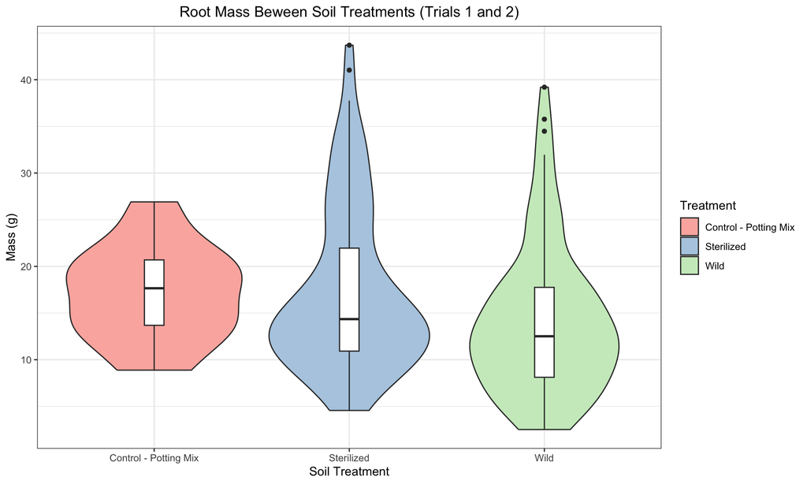

```r
ggplot(seward.data, aes(x = Treatment, y = Weight, fill = Treatment)) +
  geom_violin() +
  geom_boxplot(width = 0.1, fill = "white") +
  labs(title = "Root Mass Beween Soil Treatments (Trials 1 and 2)", y = "Mass (g)", x = "Soil Treatment") +
    scale_fill_brewer(palette = "Pastel1") +
  theme_bw() +
  theme(plot.title =  element_text(hjust = 0.5))
```

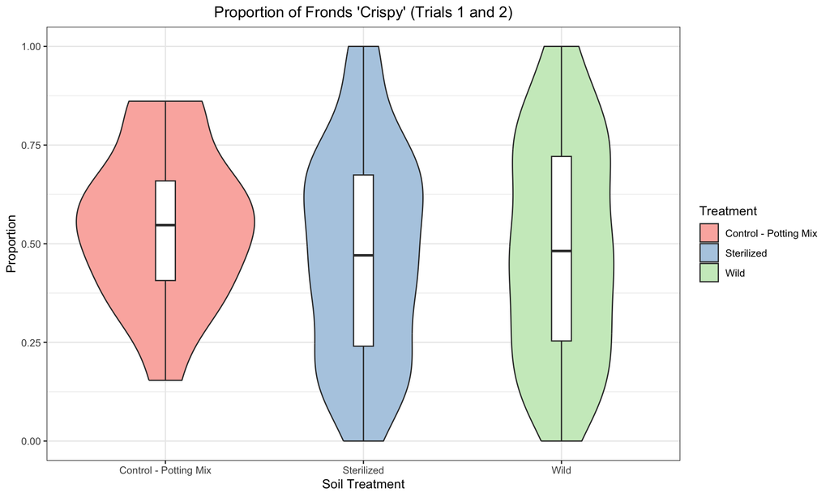

```r
ggplot(seward.data, aes(x = Treatment, y = Proportion.Crispy.Fronds, fill = Treatment)) +
  geom_violin() +
  geom_boxplot(width = 0.1, fill = "white") +
  labs(title = "Proportion of Fronds 'Crispy' (Trials 1 and 2)", y = "Proportion", x = "Soil Treatment") +
  theme_bw() +
  theme(plot.title = element_text(hjust = 0.5))+
  scale_fill_brewer(palette = "Pastel1")
```

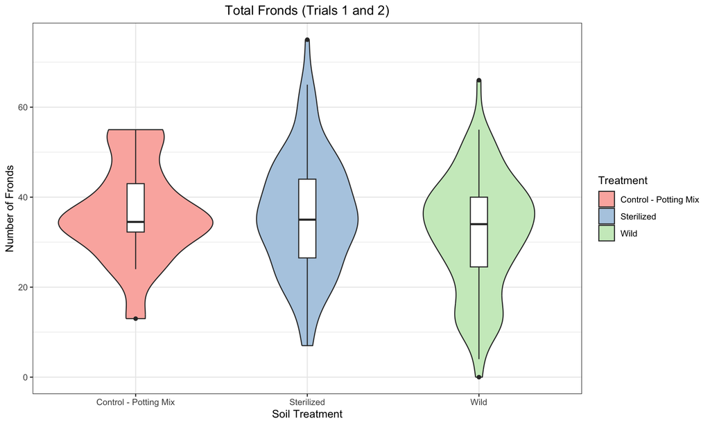

```r
ggplot(seward.data, aes(x = Treatment, y = Total.Fronds, fill = Treatment)) +
  geom_violin() +
  geom_boxplot(width = 0.1, fill = "white") +
  labs(title = "Total Fronds (Trials 1 and 2)", y = "Number of Fronds", x = "Soil Treatment") +
  theme_bw() +
  theme(plot.title = element_text(hjust = 0.5))+
  scale_fill_brewer(palette = "Pastel1")
```

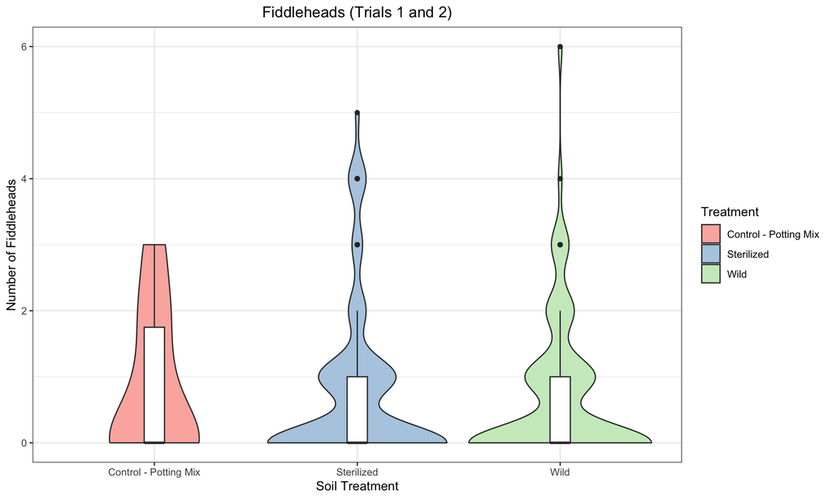

```r
ggplot(seward.data, aes(x = Treatment, y = Fiddleheads, fill = Treatment)) +
  geom_violin() +
  geom_boxplot(width = 0.1, fill = "white") +
  labs(title = "Fiddleheads (Trials 1 and 2)", y = "Number of Fiddleheads", x = "Soil Treatment") +
  theme_bw() +
  theme(plot.title = element_text(hjust = 0.5))+
  scale_fill_brewer(palette = "Pastel1")
```

### Seward Trial 1

```r
seward1 <- seward.data %>% filter(Trial.x == "Seward Trial One")

leveneTest(Total.Fronds ~ as.factor(Treatment), data = seward1, na.rm = TRUE)
```

```
## Levene's Test for Homogeneity of Variance (center = median: TRUE)
##       Df F value Pr(>F)
## group  1  0.4325 0.5125
##       84
```

```r
leveneTest(Weight ~ as.factor(Treatment), data = seward1, na.rm = TRUE)
```

```
## Levene's Test for Homogeneity of Variance (center = median: TRUE)
##       Df F value Pr(>F)
## group  1  1.8192  0.181
##       84
```

There is not enough evidence to reject equality of vairances between treatment groups for the total number of fronds and dry root weights.

#### Check for normality

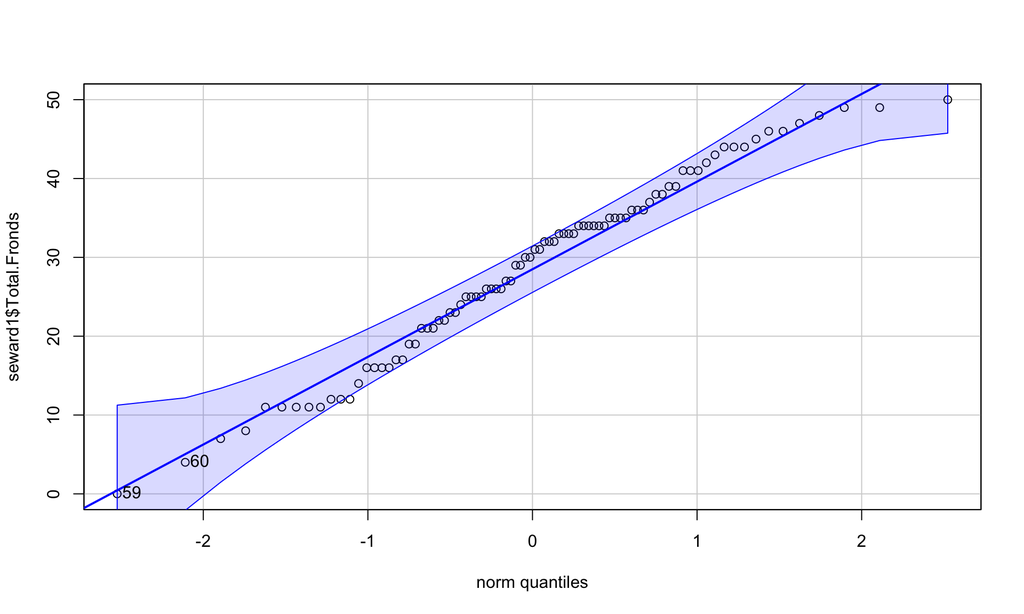

```
## [1] 59 60
```

```r
qqPlot(seward1$Total.Fronds)
```

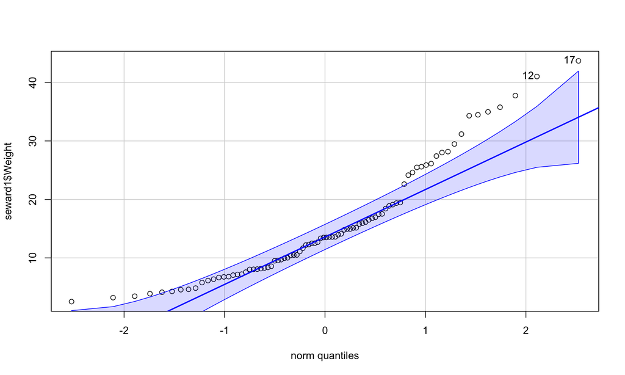

```
## [1] 17 12
```

```r
qqPlot(seward1$Weight)
```

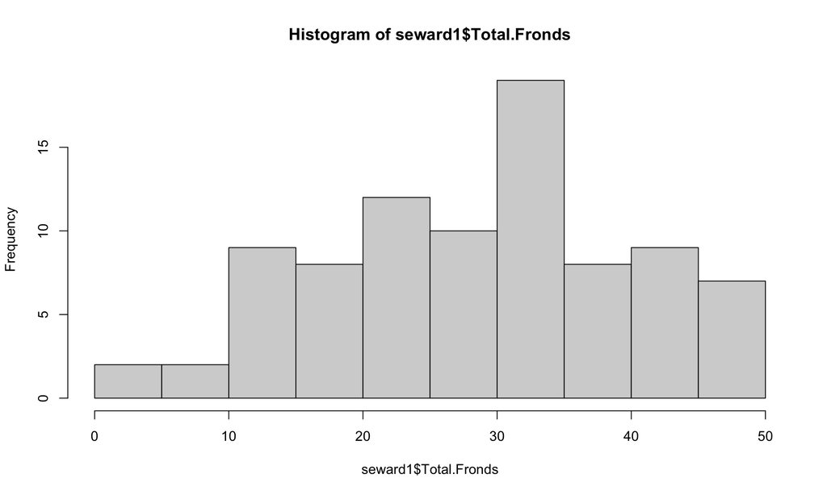

```r
hist(seward1$Total.Fronds)
```

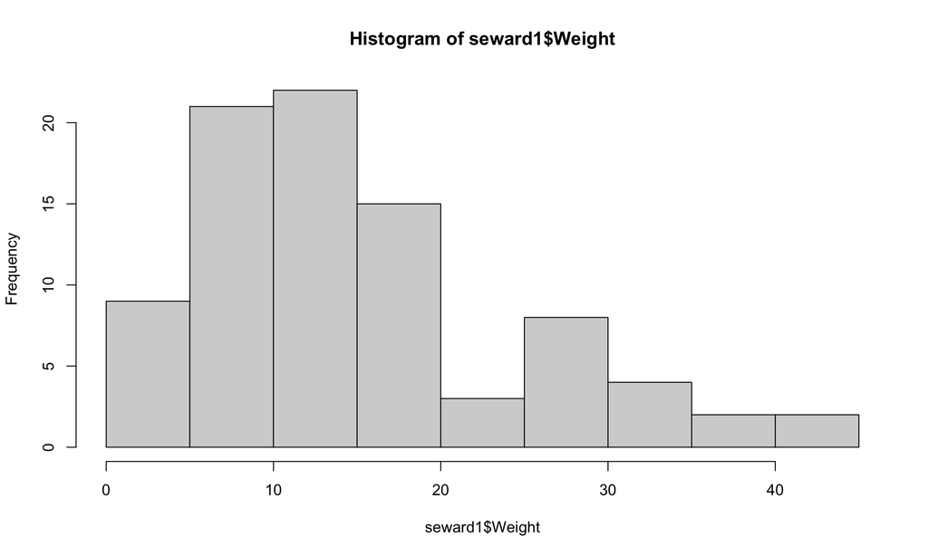

```r
hist(seward1$Weight)
```

```r
seward1 %>% shapiro_test(Total.Fronds, Weight)
```

```
## # A tibble: 2 × 3
##   variable     statistic         p
##   <chr>            <dbl>     <dbl>
## 1 Total.Fronds     0.977 0.125
## 2 Weight           0.905 0.0000108
```

```r
misty::descript(seward1$Total.Fronds)
```

```
##  Descriptive Statistics
##
##    n nNA %NA nUQ     M    SD  Min  %Min   Max  %Max  Skew  Kurt
##   86   0  0%  38 28.67 11.86 0.00 1.16% 50.00 1.16% -0.24 -0.70
```

```r
misty::descript(seward1$Weight)
```

```
##  Descriptive Statistics
##
##    n nNA %NA nUQ     M   SD  Min  %Min   Max  %Max Skew Kurt
##   86   0  0%  86 15.33 9.55 2.52 1.16% 43.70 1.16% 1.04 0.44
```

Dry swordfern root weight data not normally distributed according to visual inspection using qqPlot and histogram and the Shapiro-Wilk test for normality. Since sample size is > 20 for each group, due to the CLT and the robustness of one-way ANOVA tests, we will proceed with running an ANOVA and accept the risk of increasing type I error rate.

#### Run ANOVA on Seward Trial 1 weight data

```r
anova.seward1 <- oneway.test(`Weight` ~ Treatment, data = seward1 ,var.equal = TRUE)
anova.seward1
```

```
##
##  One-way analysis of means
##
## data:  Weight and Treatment
## F = 6.5836, num df = 1, denom df = 84, p-value = 0.01207
```

```r
seward1.aov <- aov(Weight~Treatment, data = seward1)
summary(seward1.aov)
```

```
##             Df Sum Sq Mean Sq F value Pr(>F)
## Treatment    1    564   563.6   6.584 0.0121 *
## Residuals   84   7190    85.6
## ---
## Signif. codes:  0 '***' 0.001 '**' 0.01 '*' 0.05 '.' 0.1 ' ' 1
```

```r
TukeyHSD(seward1.aov, conf.level = .95)
```

```
##   Tukey multiple comparisons of means
##     95% family-wise confidence level
##
## Fit: aov(formula = Weight ~ Treatment, data = seward1)
##
## $Treatment
##                      diff       lwr       upr    p adj
## Wild-Sterilized -5.119767 -9.087724 -1.151811 0.012067
```

Our one-way ANOVA to compare the effect of soil sterilization on root weight suggests that there was a statistically significant difference in root weights between the treatment groups (F(1, 84) = 6.5836, p = 0.01207. After performing a Tukey’s HSD post-hoc test, the true difference in mean dry root weight between wild and sterilized soil treatment groups is between -9.087724 g and -1.151811 g at a 95% confidence interval.

#### Run Chi-Squared test on Seward Trial 1 frond count data

```r
table(seward1$Treatment, seward1$Total.Fronds)
```

```
##
##              0 4 7 8 11 12 14 16 17 19 21 22 23 24 25 26 27 29 30 31 32 33 34
##   Sterilized 0 0 1 1  1  0  0  2  1  1  2  1  2  0  2  1  1  2  0  1  1  2  4
##   Wild       1 1 0 0  4  3  1  2  1  1  1  1  0  1  2  3  1  0  2  1  2  2  2
##
##              35 36 37 38 39 41 42 43 44 45 46 47 48 49 50
##   Sterilized  2  2  1  2  1  0  1  1  1  0  1  1  1  2  1
##   Wild        2  1  0  0  1  3  0  0  2  1  1  0  0  0  0
```

```r
chisq.seward1 <- chisq.test(table(seward1$Treatment, seward1$Total.Fronds))
chisq.seward1
```

```
##
##  Pearson's Chi-squared test
##
## data:  table(seward1$Treatment, seward1$Total.Fronds)
## X-squared = 33.8, df = 37, p-value = 0.6199
```

```r
freq.seward1 <- table(seward1$Treatment, seward1$Total.Fronds)
freq.seward1 <- seward1 %>% group_by(Treatment, Total.Fronds) %>% summarise(Frequency = n(), .groups = 'drop')

seward1.chi <- seward1
seward1.chi$Total.Fronds <- cut(seward1.chi$Total.Fronds,
                                       breaks = c(-1, 15, 25, 35, 45, 50),
                                       labels = c("< 15", "15-25", "26-35", "35-35", "45-50"))

chisq.seward1 <- chisq.test(table(seward1.chi$Treatment, seward1.chi$Total.Fronds))
chisq.seward1
```

```
##
##  Pearson's Chi-squared test
##
## data:  table(seward1.chi$Treatment, seward1.chi$Total.Fronds)
## X-squared = 7.634, df = 4, p-value = 0.1059
```

```r
chisq.seward1$expected
```

```
##
##              < 15 15-25 26-35 35-35 45-50
##   Sterilized  6.5    10  14.5   8.5   3.5
##   Wild        6.5    10  14.5   8.5   3.5
```

Groups were split up to create expected values > 5 for at least 80% of our groups. A Pearson’s Chi-squared test suggested that there was not a statistically significant difference in the number of fronds on sword fern plants between soil treatment groups, X^2(4, N = 86) = 7.634, p = 0.1059.

### Seward Trial 2

#### Subset data and check for equality of variances

```r
seward2 <- seward.data %>% filter(Trial.x == "Seward Trial Two")
seward2.nopot <- seward2 %>% filter(Treatment != "Control - Potting Mix")

leveneTest(Total.Fronds~as.factor(Treatment), data=seward2, na.rm = TRUE)
```

```
## Levene's Test for Homogeneity of Variance (center = median: TRUE)
##        Df F value Pr(>F)
## group   2  1.2392 0.2939
##       103
```

```r
leveneTest(Weight~as.factor(Treatment), data = seward2, na.rm = TRUE)
```

```
## Levene's Test for Homogeneity of Variance (center = median: TRUE)
##        Df F value Pr(>F)
## group   2  0.6963 0.5008
##       103
```

```r
leveneTest(Weight~as.factor(Treatment), data = seward2.nopot, na.rm = TRUE)
```

```
## Levene's Test for Homogeneity of Variance (center = median: TRUE)
##       Df F value Pr(>F)
## group  1  0.1965 0.6586
##       86
```

```r
leveneTest(Total.Fronds~as.factor(Treatment), data = seward2.nopot, na.rm = TRUE)
```

```
## Levene's Test for Homogeneity of Variance (center = median: TRUE)
##       Df F value Pr(>F)
## group  1  2.0327 0.1576
##       86
```

There is not enough evidence to reject equality of variances between treatment groups.

#### Check for normality

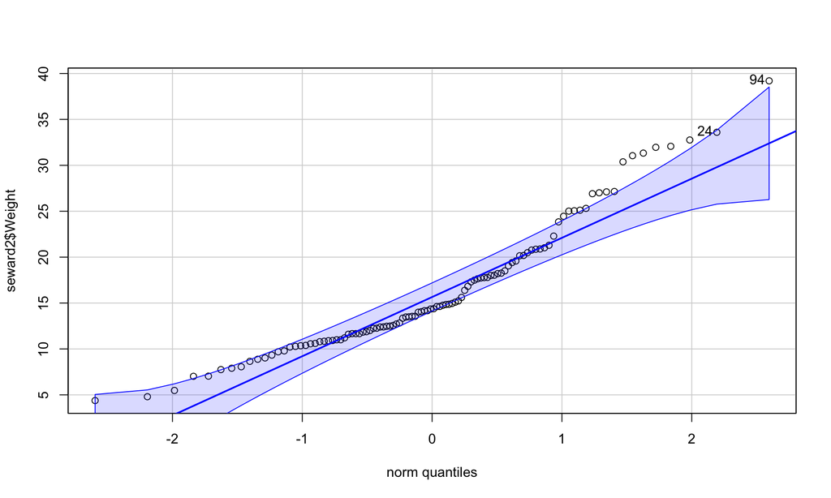

```
## [1] 94 24
```

```r
qqPlot(seward2$Weight)
```

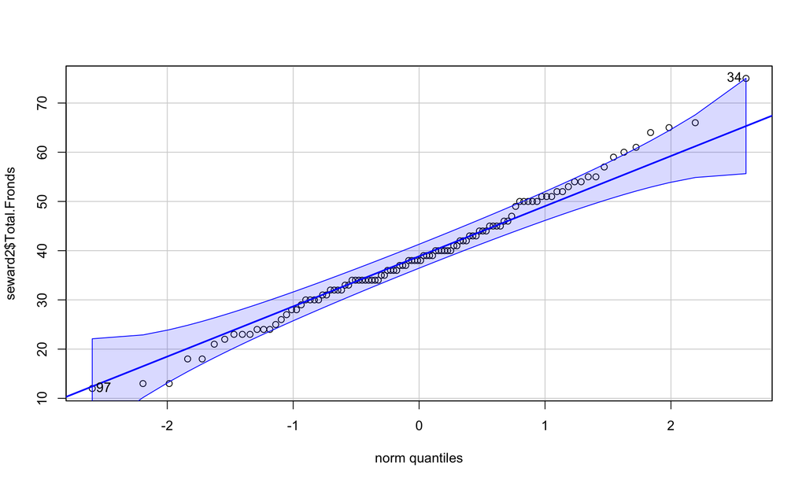

```
## [1] 34 97
```

```r
qqPlot(seward2$Total.Fronds)
```

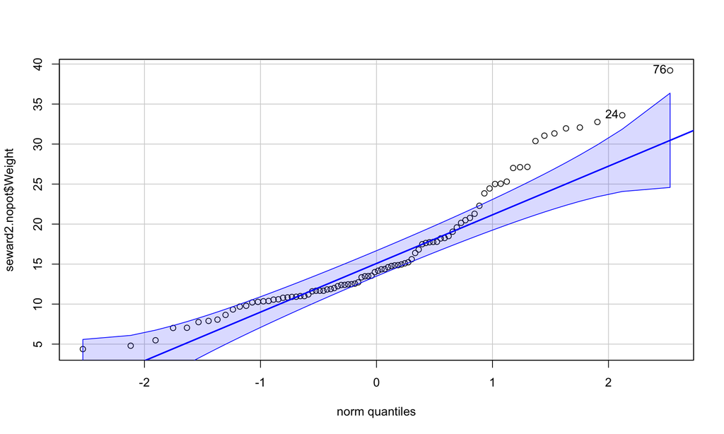

```
## [1] 76 24
```

```r
qqPlot(seward2.nopot$Weight)
```

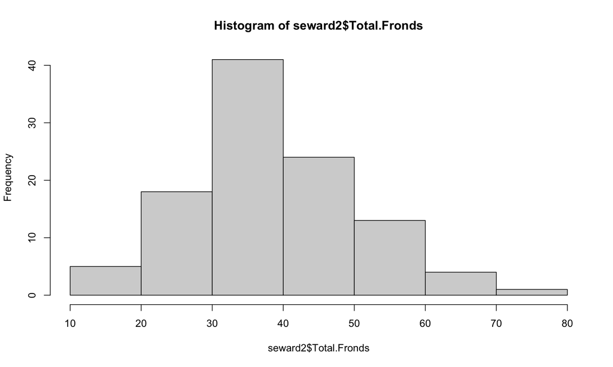

```r
hist(seward2$Total.Fronds)
```

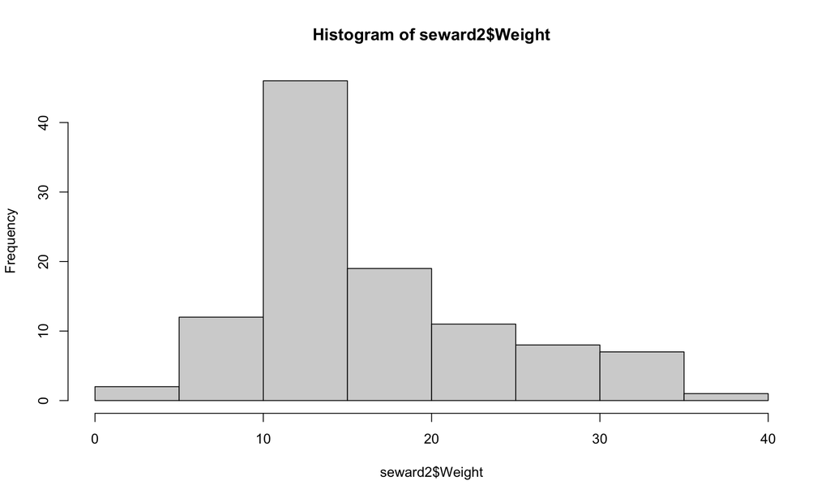

```r
hist(seward2$Weight)
```

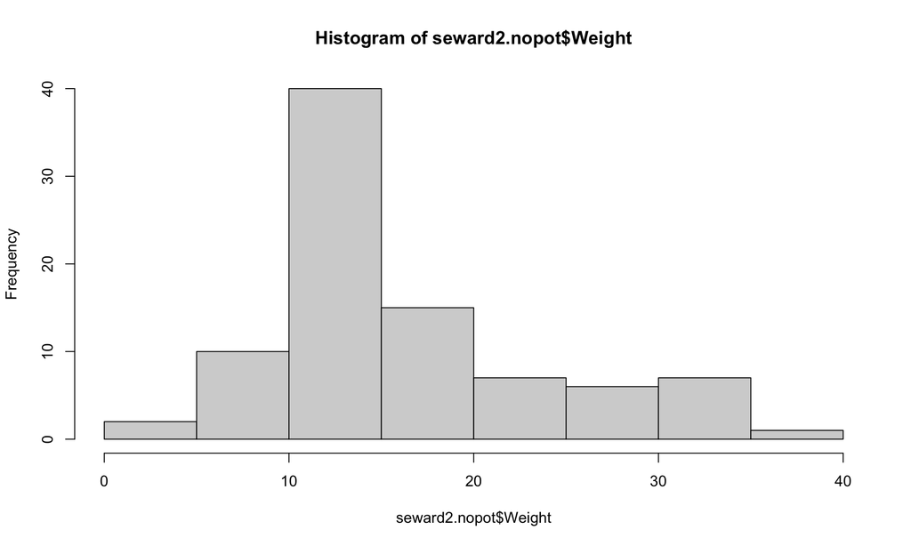

```r
hist(seward2.nopot$Weight)
```

```r
seward2 %>% shapiro_test(Total.Fronds, Weight)
```

```
## # A tibble: 2 × 3
##   variable     statistic         p
##   <chr>            <dbl>     <dbl>
## 1 Total.Fronds     0.990 0.593
## 2 Weight           0.927 0.0000196
```

```r
seward2.nopot %>% shapiro_test(Total.Fronds, Weight)
```

```
## # A tibble: 2 × 3
##   variable     statistic         p
##   <chr>            <dbl>     <dbl>
## 1 Total.Fronds     0.990 0.715
## 2 Weight           0.907 0.0000109
```

```r
misty::descript(seward2.nopot$Weight)
```

```
##  Descriptive Statistics
##
##    n nNA %NA nUQ     M   SD  Min  %Min   Max  %Max Skew Kurt
##   88   0  0%  85 16.10 7.41 4.38 1.14% 39.20 1.14% 1.04 0.49
```

```r
misty::descript(seward2.nopot$Total.Fronds)
```

```
##  Descriptive Statistics
##
##    n nNA %NA nUQ     M    SD   Min  %Min   Max  %Max Skew Kurt
##   88   0  0%  42 39.57 12.12 12.00 1.14% 75.00 1.14% 0.27 0.21
```

Dry swordfern root weight data not normally distributed according to visual inspection using qqPlot and histogram and the Shapiro-Wilk test for normality. Since sample size is > 20 for each group, due to the CLT and the robustness of one-way ANOVA tests, we will proceed with running an ANOVA and accept the risk of increasing type I error rate.

#### Run ANOVA on Seward Trail 2 weight data excluding potting soil control group

```r
anova.seward2 <- oneway.test(`Weight` ~ Treatment, data = seward2.nopot, var.equal = TRUE)
anova.seward2
```

```
##
##  One-way analysis of means
##
## data:  Weight and Treatment
## F = 0.61133, num df = 1, denom df = 86, p-value = 0.4364
```

Our one-way ANOVA suggests that there is not a statistically significant difference in dry root weights between soil treatment groups (F(1, 86) = 0.61133, p = 0.4364). The true difference in means between dry root weights between treatment groups is likely equal to 0.

```r
misty::descript(seward2.nopot$Total.Fronds)
```

```
##  Descriptive Statistics
##
##    n nNA %NA nUQ     M    SD   Min  %Min   Max  %Max Skew Kurt
##   88   0  0%  42 39.57 12.12 12.00 1.14% 75.00 1.14% 0.27 0.21
```

```r
chisq.seward2 <- chisq.test(table(seward2.nopot$Treatment, seward2.nopot$Total.Fronds))
chisq.seward2
```

```
##
##  Pearson's Chi-squared test
##
## data:  table(seward2.nopot$Treatment, seward2.nopot$Total.Fronds)
## X-squared = 49.867, df = 41, p-value = 0.1614
```

```r
freq.seward2 <- table(seward2.nopot$Treatment, seward2.nopot$Total.Fronds)
freq.seward2 <- seward2.nopot %>% group_by(Treatment, Total.Fronds) %>% summarise(Frequency = n(), .groups = 'drop')

seward2.chi <- seward2.nopot
seward2.chi$Total.Fronds <- cut(seward2.chi$Total.Fronds,
                                       breaks = c(-1, 25, 30, 35, 40, 45, 50, Inf),
                                       labels = c("< 25", "26-30", "31-35", "36-40", "41-45", "46-50", "> 50"))

chisq.seward2 <- chisq.test(table(seward2.chi$Treatment, seward2.chi$Total.Fronds))
chisq.seward2
```

```
##
##  Pearson's Chi-squared test
##
## data:  table(seward2.chi$Treatment, seward2.chi$Total.Fronds)
## X-squared = 8.6318, df = 6, p-value = 0.1954
```

```r
chisq.seward2$expected
```

```
##
##              < 25 26-30 31-35 36-40 41-45 46-50 > 50
##   Sterilized  5.5     4   6.5   9.5   6.5   4.5  7.5
##   Wild        5.5     4   6.5   9.5   6.5   4.5  7.5
```

```r
2/7
```

```
## [1] 0.2857143
```

A Pearson’s Chi-squared test suggested that there was not a statistically significant difference in the number of fronds on sword fern plants between soil treatment groups, X^2(6, N = 88) = 8.6318, p = 0.1954.

### Seward Combined Trials (1 and 2)

#### Check equality of variances (all treatment groups)

```r
leveneTest(Healthy.Fronds~as.factor(Treatment), data=seward.data, na.rm = TRUE)
```

```
## Levene's Test for Homogeneity of Variance (center = median: TRUE)
##        Df F value  Pr(>F)
## group   2  3.3896 0.03578 *
##       189
## ---
## Signif. codes:  0 '***' 0.001 '**' 0.01 '*' 0.05 '.' 0.1 ' ' 1
```

There is enough evidence to reject equality of variances between treatment groups since our p-critical value of 0.03578 was lower than our p-value of 0.05. This is likely due to the potting mix group being much smaller than the sterilized and wild soil groups. Due to this discrepancy, we will explore the data comparing only the sterilized and wild groups.

#### Check equality of variances (Wild and Sterilized groups only)

```r
seward.nopot <- seward.data %>% filter(Treatment != "Control - Potting Mix")
leveneTest(Healthy.Fronds~as.factor(Treatment), data=seward.nopot, na.rm = TRUE)
```

```
## Levene's Test for Homogeneity of Variance (center = median: TRUE)
##        Df F value Pr(>F)
## group   1  1.7767 0.1843
##       172
```

```r
leveneTest(Crispy.Fronds~as.factor(Treatment), data=seward.nopot, na.rm = TRUE)
```

```
## Levene's Test for Homogeneity of Variance (center = median: TRUE)
##        Df F value Pr(>F)
## group   1  0.5275 0.4687
##       172
```

There is not enough evidence to reject equality of variances between the number of healthy and crispy fronds between treatment groups.

#### Check normality

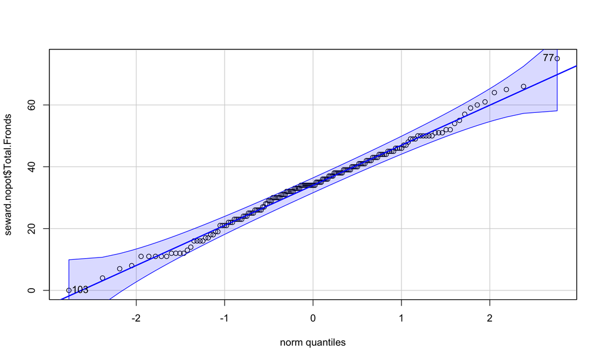

```
## [1]  77 103
```

```r
qqPlot(seward.nopot$Total.Fronds)
```

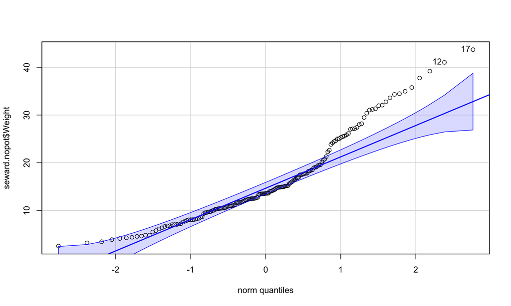

```
## [1] 17 12
```

```r
qqPlot(seward.nopot$Weight)
```

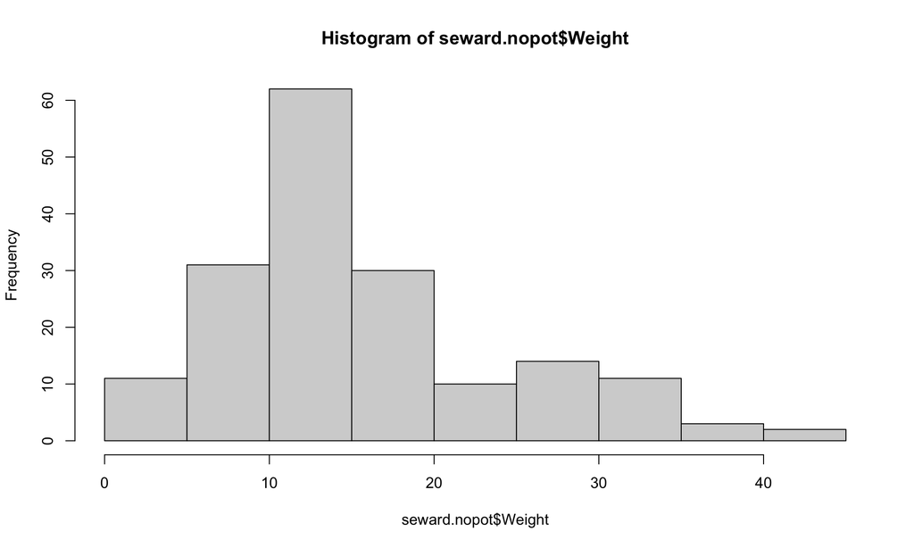

```r
hist(seward.nopot$Weight)
```

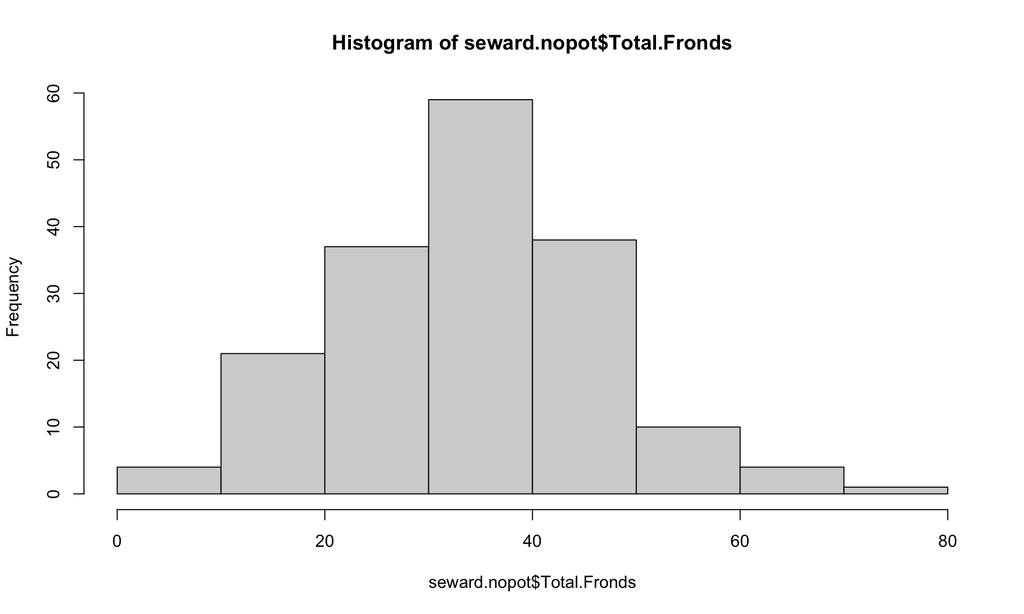

```r
hist(seward.nopot$Total.Fronds)
```

```r
misty::descript(seward.nopot)
```

```
##  Descriptive Statistics
##
##   Variable                    n nNA     %NA nUQ     M    SD  Min   %Min   Max  %Max Skew  Kurt
##    Healthy.Fronds           174   0   0.00%  42 16.83 10.61 0.00  5.17% 48.00 0.57% 0.45 -0.47
##    Crispy.Fronds            174   0   0.00%  44 17.35 12.56 0.00  2.87% 52.00 0.57% 0.69 -0.22
##    Fiddleheads              174   0   0.00%   7  0.73  1.15 0.00 59.20%  6.00 0.57% 1.94  3.78
##    Root.Rating..tentative.    0 174 100.00%   0    NA    NA   NA    NA%    NA   NA%   NA    NA
##    Number.of.Weevils         86  88  50.57%   4  0.35  0.70 0.00 75.58%  3.00 2.33% 2.11  3.95
##    Weight                   174   0   0.00% 168 15.72  8.52 2.52  0.57% 43.70 0.57% 1.03  0.59
##    Total.Fronds             174   0   0.00%  54 34.18 13.14 0.00  0.57% 75.00 0.57% 0.04  0.11
##    Proportion.Crispy.Fronds 173   1   0.57% 134  0.48  0.27 0.00  2.31%  1.00 4.62% 0.09 -0.96
```

```r
seward.nopot %>% shapiro_test(Total.Fronds, Weight)
```

```
## # A tibble: 2 × 3
##   variable     statistic            p
##   <chr>            <dbl>        <dbl>
## 1 Total.Fronds     0.993 0.606
## 2 Weight           0.918 0.0000000278
```

qqPlot and histogram for the number of total fronds are visually normally distributed. Dry swordfern root weight data not normally distributed according to visual inspection using qqPlot and histogram and the Shapiro-Wilk test for normality. Since sample size is > 20 for each group, due to the CLT and the robustness of one-way ANOVA tests, we will proceed with running an ANOVA and accept the risk of increasing type I error rate.

#### Run ANOVA on Seward root weight

```r
anova.seward <- oneway.test(`Weight` ~ Treatment, data = seward.nopot, var.equal = TRUE)
anova.seward
```

```
##
##  One-way analysis of means
##
## data:  Weight and Treatment
## F = 6.1499, num df = 1, denom df = 172, p-value = 0.0141
```

```r
seward.aov <- aov(Weight~Treatment, data = seward.nopot)
summary(seward.aov)
```

```
##              Df Sum Sq Mean Sq F value Pr(>F)
## Treatment     1    433   433.4    6.15 0.0141 *
## Residuals   172  12121    70.5
## ---
## Signif. codes:  0 '***' 0.001 '**' 0.01 '*' 0.05 '.' 0.1 ' ' 1
```

```r
TukeyHSD(seward.aov, conf.level = .95)
```

```
##   Tukey multiple comparisons of means
##     95% family-wise confidence level
##
## Fit: aov(formula = Weight ~ Treatment, data = seward.nopot)
##
## $Treatment
##                      diff       lwr        upr     p adj
## Wild-Sterilized -3.156437 -5.668766 -0.6441075 0.0141042
```

Our one-way ANOVA to compare the effect of soil sterilization on root weight suggests that there was a statistically significant difference in root weights between the treatment groups (F(1, 172) = 6.1499, p = 0.0141. After performing a Tukey’s HSD post-hoc test, the true difference in mean dry root weight between wild and sterilized soil treatment groups is between -5.668766 g and -0.6441075 g at a 95% confidence interval.

# Run Chi-Squared test on total number of fronds between treatment groups

```r
freq.seward <- table(seward.nopot$Treatment, seward.nopot$Total.Fronds)
freq.seward <- seward.nopot %>% group_by(Treatment, Total.Fronds) %>% summarise(Frequency = n(), .groups = 'drop')

seward.nopot.merge <- seward.nopot
seward.nopot.merge$Total.Fronds <- cut(seward.nopot$Total.Fronds,
                                       breaks = c(-1, 10, 15, 20, 25, 30, 35, 40, 45, 50, Inf),
                                       labels = c("< 10", "10-15", "16-20", "21-25", "26-30", "31-35", "36-40",
                                                  "41-45", "46-50", "> 50"))

freq.seward.merge <- freq.seward %>%
  group_by(Treatment, Total.Fronds) %>%
  summarise(across(c(Frequency), sum))
```

[output not shown]

```r
chisq.seward <- chisq.test(table(seward.nopot.merge$Treatment, seward.nopot.merge$Total.Fronds))
chisq.seward
```

```
##
##  Pearson's Chi-squared test
##
## data:  table(seward.nopot.merge$Treatment, seward.nopot.merge$Total.Fronds)
## X-squared = 13.468, df = 9, p-value = 0.1426
```

```r
chisq.seward$expected
```

```
##
##              < 10 10-15 16-20 21-25 26-30 31-35 36-40 41-45 46-50 > 50
##   Sterilized    2   5.5     5   9.5     9    16  13.5    11     8  7.5
##   Wild          2   5.5     5   9.5     9    16  13.5    11     8  7.5
```

```r
1/10
```

```
## [1] 0.1
```

```r
ncol(freq.seward)
```

```
## [1] 3
```

```r
54
```

```
## [1] 54
```

```r
sum(col(freq.seward))
```

```
## [1] 504
```

A Pearson’s Chi-squared test suggested that there was not a statistically significant difference in the number of fronds on sword fern plants between soil treatment groups, X^2(9, N = 174) = 13.468, p = 0.1426.

## Inoculation Trials

### Inoculation Data Cleaning and Filtering

```r
greenhouse.data <- greenhouse.data %>%
  mutate(Experiment = case_when(
    str_detect(`Trial.x`, "Inoculation") ~ "Inoculation",
    str_detect(`Trial.x`, "Seward") ~ "Seward Soil",
    TRUE ~ NA
  ))

greenhouse.data <- greenhouse.data %>%
  mutate(Treatment = case_when(
    str_detect(`Fern.Number`, "W[[:digit:]]") ~ "Wild",
    str_detect(`Fern.Number`, "NONE") ~ "No Agar No Rice",
    str_detect(`Fern.Number`, "BLA") ~ "Blank",
    str_detect(`Fern.Number`, "OCC") ~ "Phytophthora Occultans",
    str_detect(`Fern.Number`, "OBS") ~ "Phytophthora Obscura",
    str_detect(`Fern.Number`, "SYR") ~ "Phytophthora Syringae",
    str_detect(`Fern.Number`, "CAM") ~ "Phytophthora Cambivora",
    str_detect(`Fern.Number`, "CAC") ~ "Phytophthora Cactorum",
    str_detect(`Fern.Number`, "EUR") ~ "Phytophthora Europaea",
    str_detect(`Fern.Number`, "PLU") ~ "Phytophthora Plurivora",
    str_detect(`Fern.Number`, "CAM") ~ "Phytophthora Cambivora",
    str_detect(`Fern.Number`, "FLE") ~ "Phytophthora Flexuosa",
    str_detect(`Fern.Number`, "FLE") ~ "Phytophthora Flexuosa",
    str_detect(`Fern.Number`, "GIN") ~ "Globosporangium Intermedium",
    str_detect(`Fern.Number`, "C[[:digit:]]") ~ "Sterilized",
    str_detect(`Fern.Number`, "P[[:digit:]]") ~ "Control - Potting Mix",
    TRUE ~ NA
  ))

greenhouse.data <- subset(greenhouse.data, select = -c(Trial.y))
greenhouse.data <- greenhouse.data %>%
  mutate(Weight = replace_when(Weight,
    Fern.Number == "EURA062" ~ 5.3,
    Fern.Number == "EURA063" ~ 9.9,
    Fern.Number == "EURA064" ~ 2.72,
    Fern.Number == "SYRB013" ~ 4.15,
    Fern.Number == "SYRB014" ~ 5.39,
    Fern.Number == "SYRB015" ~ 4.56,
    Fern.Number == "SYRB016" ~ 5.75,
    Fern.Number == "SYRB017" ~ 14.75,
    Fern.Number == "SYRB018" ~ 8.76
      )
  )

inoc.data <- greenhouse.data %>% filter(Experiment == "Inoculation")
inoc1 <- inoc.data %>% filter(Trial.x == "Inoculation Trial One")
```

### Visualize Data

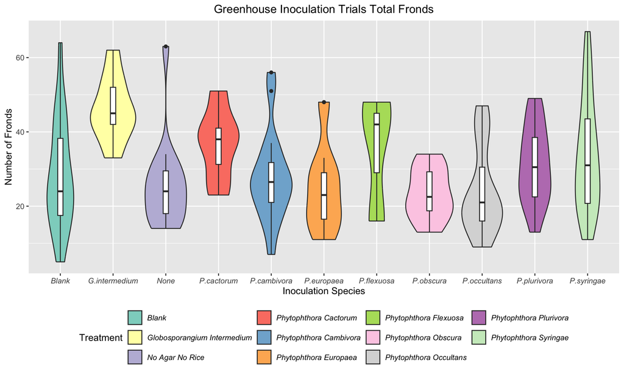

```r
total.inoc <- ggplot(inoc.data, aes(x = Treatment, y = Total.Fronds, fill = Treatment)) + geom_violin() + geom_boxplot(width=0.1, fill = "white") +
  labs(title = "Greenhouse Inoculation Trials Total Fronds", y = "Number of Fronds", x= "Inoculation Species") +
  theme(plot.title = element_text(hjust = 0.5), legend.position = "bottom", axis.text.x = element_text(face = "italic"), legend.text = element_text(face = "italic"))
total.inoc + scale_fill_brewer(palette = "Set3") + scale_x_discrete(labels = c("Blank" = "Blank","Globosporangium Intermedium" = "G.intermedium", "No Agar No Rice" = "None", "Phytophthora Cactorum" = "P.cactorum", "Phytophthora Cambivora" = "P.cambivora", "Phytophthora Europaea" = "P.europaea", "Phytophthora Flexuosa" = "P.flexuosa", "Phytophthora Obscura" = "P.obscura", "Phytophthora Occultans" = "P.occultans", "Phytophthora Plurivora" = "P.plurivora","Phytophthora Syringae" = "P.syringae"))
```

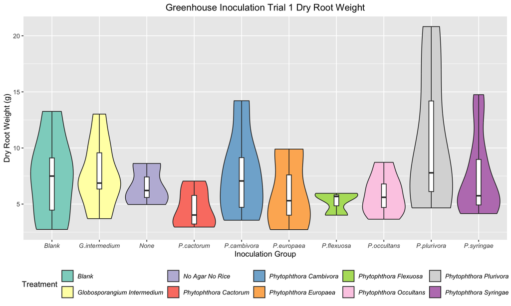

```r
weight.inoc1 <- ggplot(inoc1, aes(x = Treatment, y = Weight, fill = Treatment)) + geom_violin(scale = "width") + geom_boxplot(width=0.1, fill = "white") +
  labs(title = "Greenhouse Inoculation Trial 1 Dry Root Weight", y = "Dry Root Weight (g)", x= "Inoculation Group") + theme(plot.title = element_text(hjust = 0.5), legend.position = "bottom",  axis.text.x = element_text(face = "italic"), legend.text = element_text(face = "italic"))
weight.inoc1 + scale_fill_brewer(palette = "Set3") + scale_x_discrete(labels = c("Blank" = "Blank","Globosporangium Intermedium" = "G.intermedium", "No Agar No Rice" = "None", "Phytophthora Cactorum" = "P.cactorum", "Phytophthora Cambivora" = "P.cambivora", "Phytophthora Europaea" = "P.europaea", "Phytophthora Flexuosa" = "P.flexuosa", "Phytophthora Occultans" = "P.occultans", "Phytophthora Plurivora" = "P.plurivora","Phytophthora Syringae" = "P.syringae"))
```

### Inoculation Trial 1

#### Check data for equality of variances

```r
leveneTest(Total.Fronds ~ as.factor(Treatment), data = inoc1, na.rm =  TRUE)
```

```
## Levene's Test for Homogeneity of Variance (center = median: TRUE)
##       Df F value Pr(>F)
## group  9  0.6244 0.7706
##       50
```

```r
leveneTest(Weight ~ as.factor(Treatment), data = inoc1, na.rm = TRUE)
```

```
## Levene's Test for Homogeneity of Variance (center = median: TRUE)
##       Df F value Pr(>F)
## group  9  1.1222 0.3651
##       50
```

Not enough evidence to reject equality of variances between treatments based on the total number of fronds or dry root weight.

#### Check normality

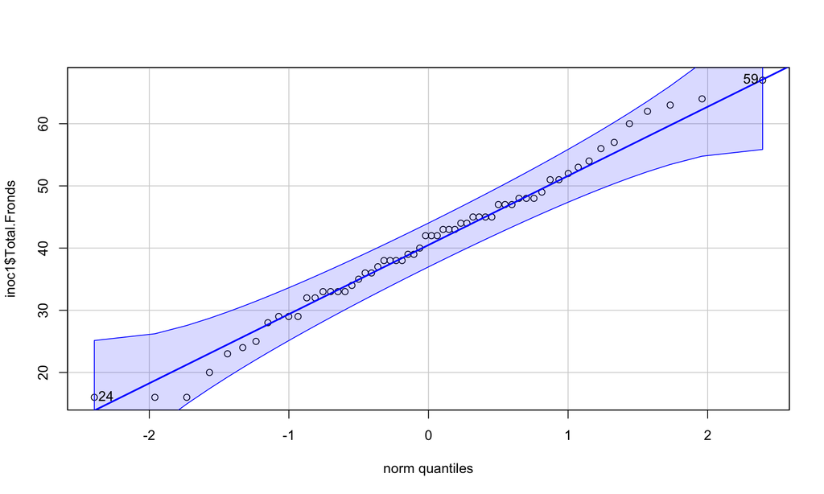

```
## [1] 59 24
```

```r
qqPlot(inoc1$Total.Fronds)
```

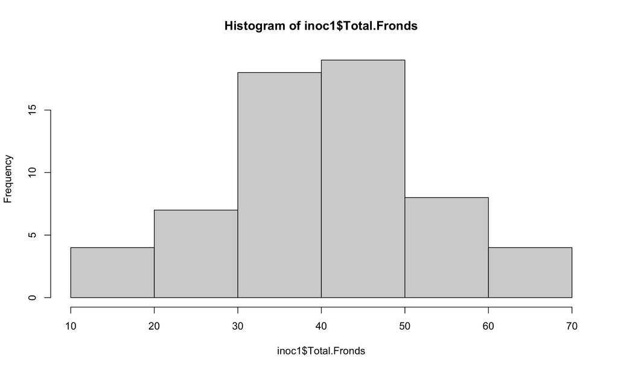

```r
hist(inoc1$Total.Fronds)
```

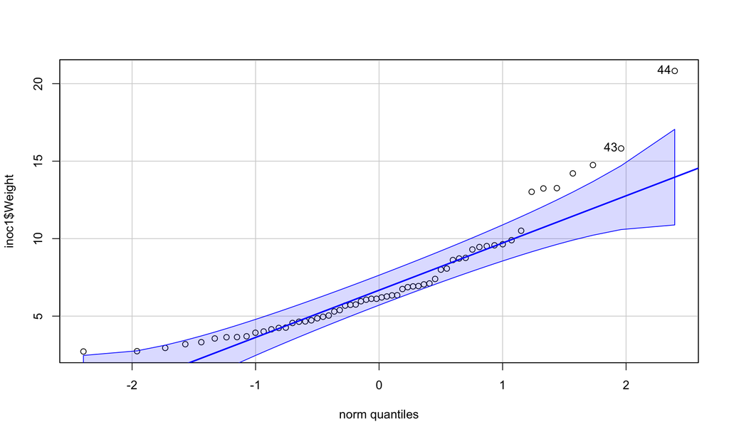

```
## [1] 44 43
```

```r
qqPlot(inoc1$Weight)
```

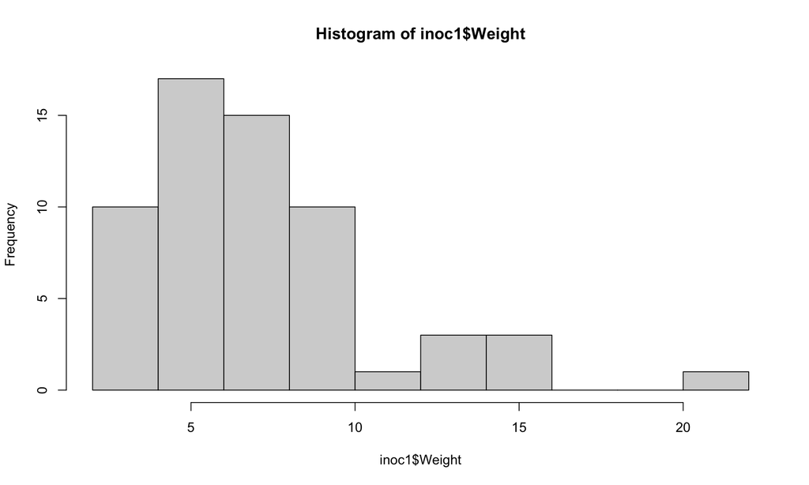

```r
hist(inoc1$Weight)
```

```r
inoc1 %>% shapiro_test(Total.Fronds, Weight)
```

```
## # A tibble: 2 × 3
##   variable     statistic         p
##   <chr>            <dbl>     <dbl>
## 1 Total.Fronds     0.986 0.732
## 2 Weight           0.870 0.0000127
```

```r
misty::descript(inoc1$Total.Fronds)
```

```
##  Descriptive Statistics
##
##    n nNA %NA nUQ     M    SD   Min  %Min   Max  %Max  Skew  Kurt
##   60   0  0%  34 40.77 11.95 16.00 5.00% 67.00 1.67% -0.03 -0.25
```

```r
misty::descript(inoc1$Weight)
```

```
##  Descriptive Statistics
##
##    n nNA %NA nUQ    M   SD  Min  %Min   Max  %Max Skew Kurt
##   60   0  0%  59 7.08 3.63 2.72 1.67% 20.82 1.67% 1.48 2.44
```

After visually checking QQ plot and histogram, the distribution for the total number of fronds for our inoculation trials data appear to be normal. To confirm a Shapiro-Wilk test was performed which yielded a non-significant result, suggesting there is not enough evidence to reject the normality of the dataset. Dry swordfern root weight data not normally distributed according to visual inspection using qqPlot and histogram and the Shapiro-Wilk test for normality. Since sample size is > 20, due to the CLT and the robustness of one-way ANOVA tests, we will proceed with running an ANOVA and accept the risk of increasing type I error rate.

#### Run ANOVA on inoculation trial 1 dry root weight data

```r
anova.inoc1 <- oneway.test(`Weight` ~ Treatment, data = inoc1, var.equal = TRUE)
anova.inoc1
```

```
##
##  One-way analysis of means
##
## data:  Weight and Treatment
## F = 1.1877, num df = 9, denom df = 50, p-value = 0.3235
```

```r
inoc1.aov <- aov(Weight~Treatment, data = inoc1)
summary(inoc1.aov)
```

```
##             Df Sum Sq Mean Sq F value Pr(>F)
## Treatment    9  136.7   15.19   1.188  0.323
## Residuals   50  639.6   12.79
```

#### Try combined control data to determine if difference

```r
inoc1.ctrl <- inoc1 %>%
  mutate(Treatment = replace_when(Treatment,
    str_detect(`Treatment`, "No Agar No Rice") ~ "Control",
    str_detect(`Treatment`, "Blank") ~ "Control"
  ))


leveneTest(Weight ~ as.factor(Treatment), data = inoc1.ctrl, na.rm = TRUE)
```

```
## Levene's Test for Homogeneity of Variance (center = median: TRUE)
##       Df F value Pr(>F)
## group  8  1.1593 0.3416
##       51
```

```r
anova.inoc1.ctrl <- oneway.test(`Weight` ~ Treatment, data = inoc1.ctrl, var.equal = TRUE)
anova.inoc1.ctrl
```

```
##
##  One-way analysis of means
##
## data:  Weight and Treatment
## F = 1.3492, num df = 8, denom df = 51, p-value = 0.2414
```

### Inoculation trial 1 Chi-Squared test on total number of fronds

try another statistical test

```r
freq.inoc1 <- table(inoc1$Treatment, inoc1$Total.Fronds)
freq.inoc1 <- inoc1 %>% group_by(Treatment, Total.Fronds) %>% summarise(Frequency = n(), .groups = 'drop')

inoc1.chisq <- inoc1
inoc1.chisq$Total.Fronds <- cut(inoc1.chisq$Total.Fronds,
                                       breaks = c(-1, 30, 40, 50, 60, Inf),
                                       labels = c("< 30", "31-40", "41-50","51-60","> 60"))

chisq.inoc1 <- chisq.test(table(inoc1.chisq$Treatment, inoc1.chisq$Total.Fronds))
chisq.inoc1
```

```
##
##  Pearson's Chi-squared test
##
## data:  table(inoc1.chisq$Treatment, inoc1.chisq$Total.Fronds)
## X-squared = 39.87, df = 36, p-value = 0.302
```

```r
chisq.inoc1$expected
```

```
##
##                               < 30 31-40 41-50 51-60 > 60
##   Blank                       1.10   1.8  1.90   0.8  0.4
##   Globosporangium Intermedium 1.65   2.7  2.85   1.2  0.6
##   No Agar No Rice             0.55   0.9  0.95   0.4  0.2
##   Phytophthora Cactorum       1.10   1.8  1.90   0.8  0.4
##   Phytophthora Cambivora      1.10   1.8  1.90   0.8  0.4
##   Phytophthora Europaea       0.55   0.9  0.95   0.4  0.2
##   Phytophthora Flexuosa       0.55   0.9  0.95   0.4  0.2
##   Phytophthora Occultans      1.10   1.8  1.90   0.8  0.4
##   Phytophthora Plurivora      1.10   1.8  1.90   0.8  0.4
##   Phytophthora Syringae       2.20   3.6  3.80   1.6  0.8
```

### Inoculation Trail 2 Data

```r
inoc2 <- inoc.data %>% filter(Trial.x == "Inoculation Trial Two")
leveneTest(Total.Fronds ~ as.factor(Treatment), data = inoc2, na.rm =  TRUE)
```

```
## Levene's Test for Homogeneity of Variance (center = median: TRUE)
##       Df F value Pr(>F)
## group  7  0.2696 0.9641
##       88
```

Not enough evidence to reject equality of variances between treatments based on the total number of fronds.

#### Check normality

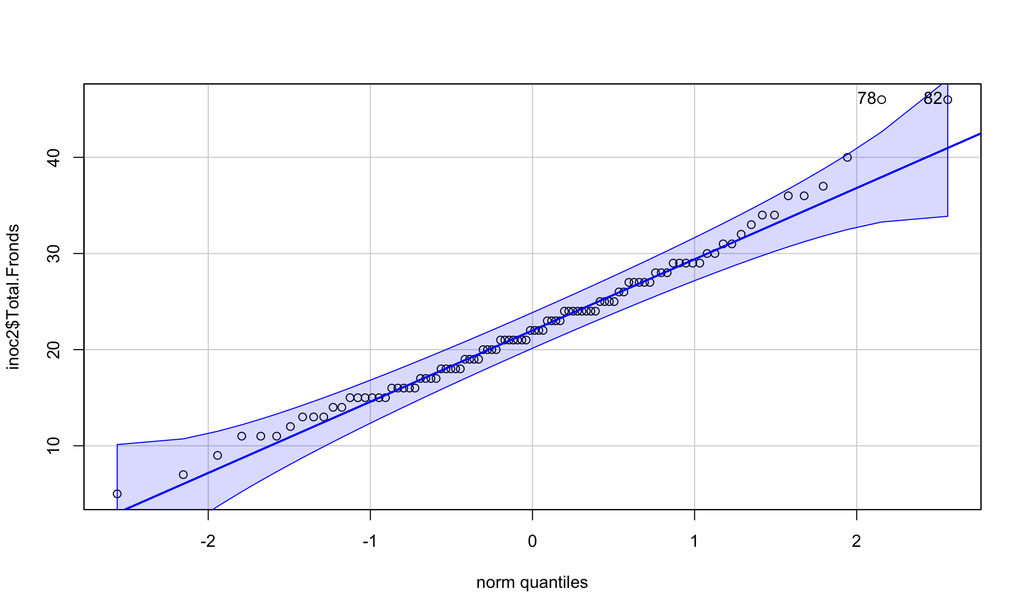

```
## [1] 78 82
```

```r
qqPlot(inoc2$Total.Fronds)
```

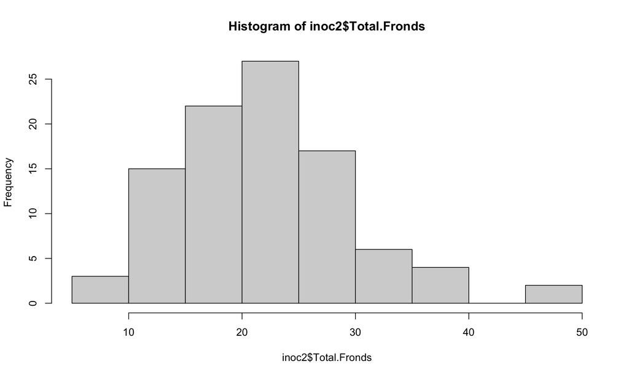

```r
hist(inoc2$Total.Fronds)
```

```r
inoc2 %>% shapiro_test(Total.Fronds)
```

```
## # A tibble: 1 × 3
##   variable     statistic      p
##   <chr>            <dbl>  <dbl>
## 1 Total.Fronds     0.977 0.0924
```

After visually checking QQ plot and histogram, the distribution for the total number of fronds for our inoculation trials data appear to be normal. To confirm a Shapiro-Wilk test was performed which yielded a non-significant result, suggesting the data is normal.

#### Combined control data

```r
inoc2.ctrl <- inoc2 %>%
  mutate(Treatment = replace_when(Treatment,
    str_detect(`Treatment`, "No Agar No Rice") ~ "Control",
    str_detect(`Treatment`, "Blank") ~ "Control"
  ))
```

### Combined Trial Data

#### Check data for equality of variances

```r
leveneTest(Total.Fronds ~ as.factor(Treatment), data = inoc.data, na.rm =  TRUE)
```

```
## Levene's Test for Homogeneity of Variance (center = median: TRUE)
##        Df F value Pr(>F)
## group  10  0.8965 0.5382
##       145
```

Not enough evidence to reject equality of variances between treatments based on the total number of fronds.

#### Check normality

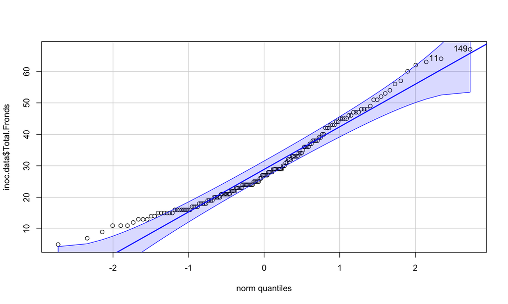

```
## [1] 149  11
```

```r
qqPlot(inoc.data$Total.Fronds)
```

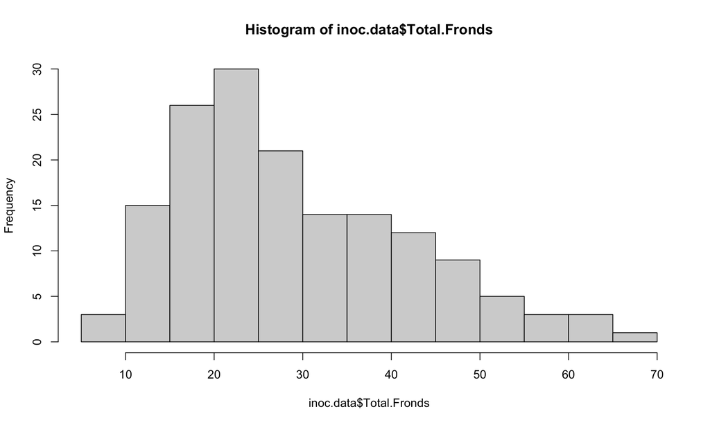

```r
hist(inoc.data$Total.Fronds)
```

```r
inoc.data %>% shapiro_test(Total.Fronds)
```

```
## # A tibble: 1 × 3
##   variable     statistic         p
##   <chr>            <dbl>     <dbl>
## 1 Total.Fronds     0.954 0.0000524
```

After visually checking QQ plot and histogram, the distribution for the total number of fronds for our inoculation trials data appear to be non-normal. To confirm a Shapiro-Wilk test was performed which yielded a significant result, suggesting the data is not normal.

#### Combine controls for inoculation trials

```r
inoc.control <- inoc.data %>%
  mutate(Treatment = replace_when(Treatment,
    str_detect(`Treatment`, "No Agar No Rice") ~ "Control",
    str_detect(`Treatment`, "Blank") ~ "Control"
  ))

leveneTest(Total.Fronds ~ as.factor(Treatment), data = inoc.control, na.rm = TRUE)
```

```
## Levene's Test for Homogeneity of Variance (center = median: TRUE)
##        Df F value Pr(>F)
## group   9  0.8292 0.5902
##       146
```

Not enough evidence to reject equality of variances.

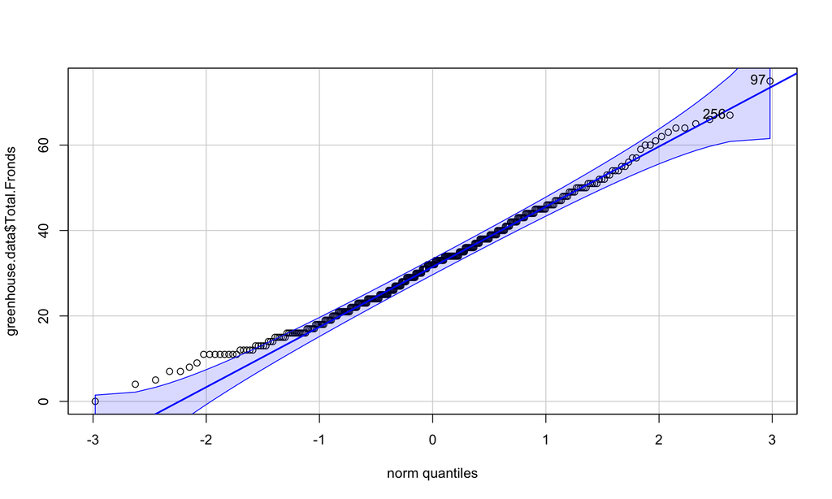

```
## [1]  97 256
```

```r
greenhouse.data$cryptogea <- "No"

greenhouse.data <- greenhouse.data %>%
  mutate(cryptogea = replace_when(cryptogea,
    str_detect(`Fern.Number`, "BLAB6") ~ "Yes",
    str_detect(`Fern.Number`, "OCCB2") ~ "Yes",
    str_detect(`Fern.Number`, "EURA5") ~ "Yes",
    str_detect(`Fern.Number`, "SYRA1") ~ "Yes",
    str_detect(`Fern.Number`, "EURB6") ~ "Yes",
    str_detect(`Fern.Number`, "PLUB1") ~ "Yes",
    str_detect(`Fern.Number`, "PLUA4") ~ "Yes",
    str_detect(`Fern.Number`, "EURB5") ~ "Yes",
    str_detect(`Fern.Number`, "W70") ~ "Yes",
    str_detect(`Fern.Number`, "W72") ~ "Yes",
    str_detect(`Fern.Number`, "C72") ~ "Yes",
    str_detect(`Fern.Number`, "C51") ~ "Yes",
    str_detect(`Fern.Number`, "W61") ~ "Yes",
    str_detect(`Fern.Number`, "GINA130") ~ "Yes",
  ))

qqPlot(greenhouse.data$Total.Fronds)
```

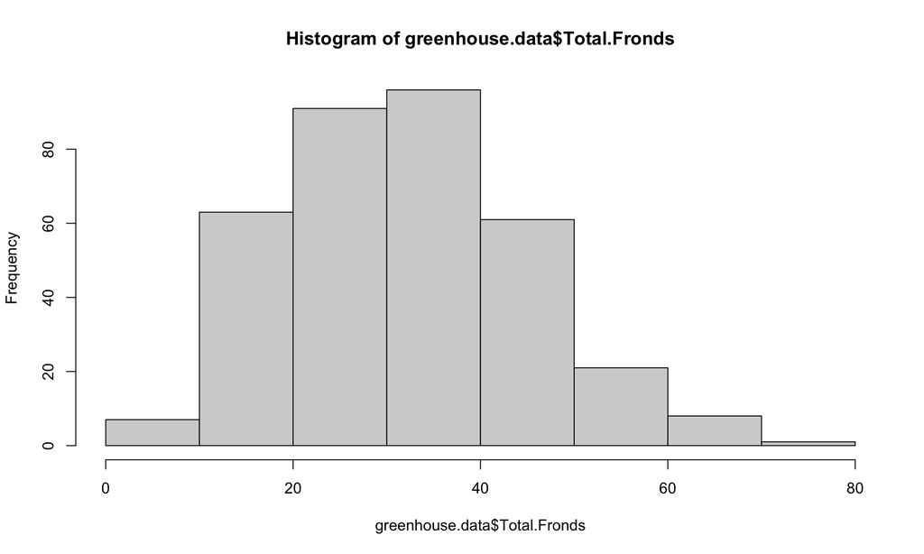

```r
hist(greenhouse.data$Total.Fronds)
```

```r
greenhouse.data %>% shapiro_test(Total.Fronds)
```

```
## # A tibble: 1 × 3
##   variable     statistic      p
##   <chr>            <dbl>  <dbl>
## 1 Total.Fronds     0.990 0.0153
```

Enough evidence to reject normality from visual inspection of QQ plot and histogram as well as a significant result from the Shapiro-Wilk test.

```r
wilcox.test(Total.Fronds ~ cryptogea, data=greenhouse.data)
```

```
##
##  Wilcoxon rank sum test with continuity correction
##
## data:  Total.Fronds by cryptogea
## W = 3166.5, p-value = 0.0247
## alternative hypothesis: true location shift is not equal to 0
```

At .05 significance level, within all greenhouse samples, we conclude that the distribution of total number of fronds in samples infected with Phytophthora cryptogea compared to samples not infected with Phytophthora cryptogea are nonidentical populations.